# Table of Contents

## For and While

### For Loop

To repeats a statement or group of for a fixed number of times.

```r
vector <- c("aaa","bbb","ccc")
 for(i in vector){
   print(i)
}
```

```
[1] "aaa"
[1] "bbb"
[1] "ccc"
```

```
[1] "aaa"
[1] "bbb"
[1] "ccc"
```

```r
for (year in c(2010,2011,2012,2013,2014,2015)){
  print(paste("The year is", year))
}
```

```
[1] "The year is 2010"
[1] "The year is 2011"
[1] "The year is 2012"
[1] "The year is 2013"
[1] "The year is 2014"
[1] "The year is 2015"
```

```
[1] "The year is 2010"
[1] "The year is 2011"
[1] "The year is 2012"
[1] "The year is 2013"
[1] "The year is 2014"
[1] "The year is 2015"
```

```r
for(i in 2:5){
    z <- i +1
    print(z)
}
```

```
[1] 3
[1] 4
[1] 5
[1] 6
```

```
[1] 3
[1] 4
[1] 5
[1] 6
```

| Instead of | Use |
| --- | --- |
| 1:length(x) | seq_along(x) |
| 1:n | seq_len(n) |

```r
x <- c('a', 'b', 'c', 'd')
for (i in seq_along(x)){
    print(x[i])
}

#alternatively
for (words in x){
    print(words)
}
```

```
[1] "a"
[1] "b"
[1] "c"
[1] "d"
[1] "a"
[1] "b"
[1] "c"
[1] "d"
```

```
[1] "a"
[1] "b"
[1] "c"
[1] "d"
[1] "a"
[1] "b"
[1] "c"
[1] "d"
```

```r
mymat <- matrix(1:9,3,3)
mymat

for (i in seq_len(nrow(mymat))){
    for (j in seq_len(ncol(mymat))){
        print(mymat[i,j])
    }
}
```

| 1 | 4 | 7 |
| --- | --- | --- |
| 2 | 5 | 8 |
| 3 | 6 | 9 |

```
[1] 1
[1] 4
[1] 7
[1] 2
[1] 5
[1] 8
[1] 3
[1] 6
[1] 9
```

| 1 | 4 | 7 |
| --- | --- | --- |
| 2 | 5 | 8 |
| 3 | 6 | 9 |

```
[1] 1
[1] 4
[1] 7
[1] 2
[1] 5
[1] 8
[1] 3
[1] 6
[1] 9
```

```r
x <- head(women,10)
x
mrnull <- NULL
for(i in seq_along(x[,1])){
    concat <- c(mrnull, mean(as.numeric(x[i, 1:2])))
    print(concat)
}
```

| height | weight |
| --- | --- |
| 58 | 115 |
| 59 | 117 |
| 60 | 120 |
| 61 | 123 |
| 62 | 126 |
| 63 | 129 |
| 64 | 132 |
| 65 | 135 |
| 66 | 139 |
| 67 | 142 |

```
[1] 86.5
[1] 88
[1] 90
[1] 92
[1] 94
[1] 96
[1] 98
[1] 100
[1] 102.5
[1] 104.5
```

| height | weight |
| --- | --- |
| 58 | 115 |
| 59 | 117 |
| 60 | 120 |
| 61 | 123 |
| 62 | 126 |
| 63 | 129 |
| 64 | 132 |
| 65 | 135 |
| 66 | 139 |
| 67 | 142 |

```
[1] 86.5
[1] 88
[1] 90
[1] 92
[1] 94
[1] 96
[1] 98
[1] 100
[1] 102.5
[1] 104.5
```

```r
# Create your three-dimensional array
my_array <- array(1:20, dim=c(20, 20, 20))

for (i in 1:dim(my_array)[1]) {
  for (j in 1:dim(my_array)[2]) {
    for (k in 1:dim(my_array)[3]) {
      my_array[i,j,k] = i*j*k
    }
  }
}

# Show a 10x10x15 chunk of your array
print(my_array[1:10, 1:10, 1:15])
```

```
, , 1

      [,1] [,2] [,3] [,4] [,5] [,6] [,7] [,8] [,9] [,10]
 [1,]    1    2    3    4    5    6    7    8    9    10
 [2,]    2    4    6    8   10   12   14   16   18    20
 [3,]    3    6    9   12   15   18   21   24   27    30
 [4,]    4    8   12   16   20   24   28   32   36    40
 [5,]    5   10   15   20   25   30   35   40   45    50
 [6,]    6   12   18   24   30   36   42   48   54    60
 [7,]    7   14   21   28   35   42   49   56   63    70
 [8,]    8   16   24   32   40   48   56   64   72    80
 [9,]    9   18   27   36   45   54   63   72   81    90
[10,]   10   20   30   40   50   60   70   80   90   100

, , 2
```

[output cut: 194 more lines]

```
, , 1

      [,1] [,2] [,3] [,4] [,5] [,6] [,7] [,8] [,9] [,10]
 [1,]    1    2    3    4    5    6    7    8    9    10
 [2,]    2    4    6    8   10   12   14   16   18    20
 [3,]    3    6    9   12   15   18   21   24   27    30
 [4,]    4    8   12   16   20   24   28   32   36    40
 [5,]    5   10   15   20   25   30   35   40   45    50
 [6,]    6   12   18   24   30   36   42   48   54    60
 [7,]    7   14   21   28   35   42   49   56   63    70
 [8,]    8   16   24   32   40   48   56   64   72    80
 [9,]    9   18   27   36   45   54   63   72   81    90
[10,]   10   20   30   40   50   60   70   80   90   100

, , 2

      [,1] [,2] [,3] [,4] [,5] [,6] [,7] [,8] [,9] [,10]
 [1,]    2    4    6    8   10   12   14   16   18    20
 [2,]    4    8   12   16   20   24   28   32   36    40
 [3,]    6   12   18   24   30   36   42   48   54    60
 [4,]    8   16   24   32   40   48   56   64   72    80
 [5,]   10   20   30   40   50   60   70   80   90   100
 [6,]   12   24   36   48   60   72   84   96  108   120
 [7,]   14   28   42   56   70   84   98  112  126   140
 [8,]   16   32   48   64   80   96  112  128  144   160
 [9,]   18   36   54   72   90  108  126  144  162   180
[10,]   20   40   60   80  100  120  140  160  180   200

, , 3

      [,1] [,2] [,3] [,4] [,5] [,6] [,7] [,8] [,9] [,10]
 [1,]    3    6    9   12   15   18   21   24   27    30
 [2,]    6   12   18   24   30   36   42   48   54    60
 [3,]    9   18   27   36   45   54   63   72   81    90
 [4,]   12   24   36   48   60   72   84   96  108   120
 [5,]   15   30   45   60   75   90  105  120  135   150
 [6,]   18   36   54   72   90  108  126  144  162   180
 [7,]   21   42   63   84  105  126  147  168  189   210
 [8,]   24   48   72   96  120  144  168  192  216   240
 [9,]   27   54   81  108  135  162  189  216  243   270
[10,]   30   60   90  120  150  180  210  240  270   300

, , 4

      [,1] [,2] [,3] [,4] [,5] [,6] [,7] [,8] [,9] [,10]
 [1,]    4    8   12   16   20   24   28   32   36    40
 [2,]    8   16   24   32   40   48   56   64   72    80
 [3,]   12   24   36   48   60   72   84   96  108   120
 [4,]   16   32   48   64   80   96  112  128  144   160
 [5,]   20   40   60   80  100  120  140  160  180   200
 [6,]   24   48   72   96  120  144  168  192  216   240
 [7,]   28   56   84  112  140  168  196  224  252   280
 [8,]   32   64   96  128  160  192  224  256  288   320
 [9,]   36   72  108  144  180  216  252  288  324   360
[10,]   40   80  120  160  200  240  280  320  360   400

, , 5

      [,1] [,2] [,3] [,4] [,5] [,6] [,7] [,8] [,9] [,10]
 [1,]    5   10   15   20   25   30   35   40   45    50
 [2,]   10   20   30   40   50   60   70   80   90   100
 [3,]   15   30   45   60   75   90  105  120  135   150
 [4,]   20   40   60   80  100  120  140  160  180   200
 [5,]   25   50   75  100  125  150  175  200  225   250
 [6,]   30   60   90  120  150  180  210  240  270   300
 [7,]   35   70  105  140  175  210  245  280  315   350
 [8,]   40   80  120  160  200  240  280  320  360   400
 [9,]   45   90  135  180  225  270  315  360  405   450
[10,]   50  100  150  200  250  300  350  400  450   500

, , 6

      [,1] [,2] [,3] [,4] [,5] [,6] [,7] [,8] [,9] [,10]
 [1,]    6   12   18   24   30   36   42   48   54    60
 [2,]   12   24   36   48   60   72   84   96  108   120
 [3,]   18   36   54   72   90  108  126  144  162   180
 [4,]   24   48   72   96  120  144  168  192  216   240
 [5,]   30   60   90  120  150  180  210  240  270   300
 [6,]   36   72  108  144  180  216  252  288  324   360
 [7,]   42   84  126  168  210  252  294  336  378   420
 [8,]   48   96  144  192  240  288  336  384  432   480
 [9,]   54  108  162  216  270  324  378  432  486   540
[10,]   60  120  180  240  300  360  420  480  540   600

, , 7

      [,1] [,2] [,3] [,4] [,5] [,6] [,7] [,8] [,9] [,10]
 [1,]    7   14   21   28   35   42   49   56   63    70
 [2,]   14   28   42   56   70   84   98  112  126   140
 [3,]   21   42   63   84  105  126  147  168  189   210
 [4,]   28   56   84  112  140  168  196  224  252   280
 [5,]   35   70  105  140  175  210  245  280  315   350
 [6,]   42   84  126  168  210  252  294  336  378   420
 [7,]   49   98  147  196  245  294  343  392  441   490
 [8,]   56  112  168  224  280  336  392  448  504   560
 [9,]   63  126  189  252  315  378  441  504  567   630
[10,]   70  140  210  280  350  420  490  560  630   700

, , 8

      [,1] [,2] [,3] [,4] [,5] [,6] [,7] [,8] [,9] [,10]
 [1,]    8   16   24   32   40   48   56   64   72    80
 [2,]   16   32   48   64   80   96  112  128  144   160
 [3,]   24   48   72   96  120  144  168  192  216   240
 [4,]   32   64   96  128  160  192  224  256  288   320
 [5,]   40   80  120  160  200  240  280  320  360   400
 [6,]   48   96  144  192  240  288  336  384  432   480
 [7,]   56  112  168  224  280  336  392  448  504   560
 [8,]   64  128  192  256  320  384  448  512  576   640
 [9,]   72  144  216  288  360  432  504  576  648   720
[10,]   80  160  240  320  400  480  560  640  720   800

, , 9

      [,1] [,2] [,3] [,4] [,5] [,6] [,7] [,8] [,9] [,10]
 [1,]    9   18   27   36   45   54   63   72   81    90
 [2,]   18   36   54   72   90  108  126  144  162   180
 [3,]   27   54   81  108  135  162  189  216  243   270
 [4,]   36   72  108  144  180  216  252  288  324   360
 [5,]   45   90  135  180  225  270  315  360  405   450
 [6,]   54  108  162  216  270  324  378  432  486   540
 [7,]   63  126  189  252  315  378  441  504  567   630
 [8,]   72  144  216  288  360  432  504  576  648   720
 [9,]   81  162  243  324  405  486  567  648  729   810
[10,]   90  180  270  360  450  540  630  720  810   900

, , 10

      [,1] [,2] [,3] [,4] [,5] [,6] [,7] [,8] [,9] [,10]
 [1,]   10   20   30   40   50   60   70   80   90   100
 [2,]   20   40   60   80  100  120  140  160  180   200
 [3,]   30   60   90  120  150  180  210  240  270   300
 [4,]   40   80  120  160  200  240  280  320  360   400
 [5,]   50  100  150  200  250  300  350  400  450   500
 [6,]   60  120  180  240  300  360  420  480  540   600
 [7,]   70  140  210  280  350  420  490  560  630   700
 [8,]   80  160  240  320  400  480  560  640  720   800
 [9,]   90  180  270  360  450  540  630  720  810   900
[10,]  100  200  300  400  500  600  700  800  900  1000

, , 11

      [,1] [,2] [,3] [,4] [,5] [,6] [,7] [,8] [,9] [,10]
 [1,]   11   22   33   44   55   66   77   88   99   110
 [2,]   22   44   66   88  110  132  154  176  198   220
 [3,]   33   66   99  132  165  198  231  264  297   330
 [4,]   44   88  132  176  220  264  308  352  396   440
 [5,]   55  110  165  220  275  330  385  440  495   550
 [6,]   66  132  198  264  330  396  462  528  594   660
 [7,]   77  154  231  308  385  462  539  616  693   770
 [8,]   88  176  264  352  440  528  616  704  792   880
 [9,]   99  198  297  396  495  594  693  792  891   990
[10,]  110  220  330  440  550  660  770  880  990  1100

, , 12

      [,1] [,2] [,3] [,4] [,5] [,6] [,7] [,8] [,9] [,10]
 [1,]   12   24   36   48   60   72   84   96  108   120
 [2,]   24   48   72   96  120  144  168  192  216   240
 [3,]   36   72  108  144  180  216  252  288  324   360
 [4,]   48   96  144  192  240  288  336  384  432   480
 [5,]   60  120  180  240  300  360  420  480  540   600
 [6,]   72  144  216  288  360  432  504  576  648   720
 [7,]   84  168  252  336  420  504  588  672  756   840
 [8,]   96  192  288  384  480  576  672  768  864   960
 [9,]  108  216  324  432  540  648  756  864  972  1080
[10,]  120  240  360  480  600  720  840  960 1080  1200

, , 13

      [,1] [,2] [,3] [,4] [,5] [,6] [,7] [,8] [,9] [,10]
 [1,]   13   26   39   52   65   78   91  104  117   130
 [2,]   26   52   78  104  130  156  182  208  234   260
 [3,]   39   78  117  156  195  234  273  312  351   390
 [4,]   52  104  156  208  260  312  364  416  468   520
 [5,]   65  130  195  260  325  390  455  520  585   650
 [6,]   78  156  234  312  390  468  546  624  702   780
 [7,]   91  182  273  364  455  546  637  728  819   910
 [8,]  104  208  312  416  520  624  728  832  936  1040
 [9,]  117  234  351  468  585  702  819  936 1053  1170
[10,]  130  260  390  520  650  780  910 1040 1170  1300

, , 14

      [,1] [,2] [,3] [,4] [,5] [,6] [,7] [,8] [,9] [,10]
 [1,]   14   28   42   56   70   84   98  112  126   140
 [2,]   28   56   84  112  140  168  196  224  252   280
 [3,]   42   84  126  168  210  252  294  336  378   420
 [4,]   56  112  168  224  280  336  392  448  504   560
 [5,]   70  140  210  280  350  420  490  560  630   700
 [6,]   84  168  252  336  420  504  588  672  756   840
 [7,]   98  196  294  392  490  588  686  784  882   980
 [8,]  112  224  336  448  560  672  784  896 1008  1120
 [9,]  126  252  378  504  630  756  882 1008 1134  1260
[10,]  140  280  420  560  700  840  980 1120 1260  1400

, , 15

      [,1] [,2] [,3] [,4] [,5] [,6] [,7] [,8] [,9] [,10]
 [1,]   15   30   45   60   75   90  105  120  135   150
 [2,]   30   60   90  120  150  180  210  240  270   300
 [3,]   45   90  135  180  225  270  315  360  405   450
 [4,]   60  120  180  240  300  360  420  480  540   600
 [5,]   75  150  225  300  375  450  525  600  675   750
 [6,]   90  180  270  360  450  540  630  720  810   900
 [7,]  105  210  315  420  525  630  735  840  945  1050
 [8,]  120  240  360  480  600  720  840  960 1080  1200
 [9,]  135  270  405  540  675  810  945 1080 1215  1350
[10,]  150  300  450  600  750  900 1050 1200 1350  1500
```

### While Loop

Loop until a specific condition is met

```r
i <- 1

while (i < 6) {
   print(i)
   i = i+1
}
```

```
[1] 1
[1] 2
[1] 3
[1] 4
[1] 5
```

```
[1] 1
[1] 2
[1] 3
[1] 4
[1] 5
```

```r
a <- 0
b <- 1
print(a)
while (b < 50) {
    print(b)
    temp <- a + b
    a <- b
    b <- temp
}
```

```
[1] 0
[1] 1
[1] 1
[1] 2
[1] 3
[1] 5
[1] 8
[1] 13
[1] 21
[1] 34
```

```
[1] 0
[1] 1
[1] 1
[1] 2
[1] 3
[1] 5
[1] 8
[1] 13
[1] 21
[1] 34
```

```r
a <- 0
b <- 1
print(a)
while (b < 50) {
     print(b)
     temp <- a + b
     a <- b
     b <- temp
}
```

```
[1] 0
[1] 1
[1] 1
[1] 2
[1] 3
[1] 5
[1] 8
[1] 13
[1] 21
[1] 34
```

```
[1] 0
[1] 1
[1] 1
[1] 2
[1] 3
[1] 5
[1] 8
[1] 13
[1] 21
[1] 34
```

## repeat, break, next and switch

### Repeat statement

Iterate over a block of code multiple number of times.

```r
x <- 1

repeat {
   print(x)
   x = x+1
   if (x == 6){
       break
   }
}
```

```
[1] 1
[1] 2
[1] 3
[1] 4
[1] 5
```

```
[1] 1
[1] 2
[1] 3
[1] 4
[1] 5
```

### Break Statement

break is used inside any loop like `repeat`, `for` or `while` to stop the iterations and flow the control outside of the loop.

```r
x <- 1:5

for (val in x) {
    if (val == 3){
        break
    }
    print(val)
}
```

```
[1] 1
[1] 2
```

```
[1] 1
[1] 2
```

```r
x <- 1:10
for (num in x){
    if (num==6) break
    mynum <- paste(num, "and so on. ", sep = " ")
    print(mynum)
}
```

```
[1] "1 and so on. "
[1] "2 and so on. "
[1] "3 and so on. "
[1] "4 and so on. "
[1] "5 and so on. "
```

```
[1] "1 and so on. "
[1] "2 and so on. "
[1] "3 and so on. "
[1] "4 and so on. "
[1] "5 and so on. "
```

### Next Statment

- Useful to controls the flow of R loops
- generaal usage inside the For Loop and While Loop

**Example:**

```r
x <- 1:5

for (val in x) {
    if (val == 3){
        next
    }
    print(val)
}
```

```
[1] 1
[1] 2
[1] 4
[1] 5
```

```
[1] 1
[1] 2
[1] 4
[1] 5
```

```r
m=20
odd=numeric()

for (k in 1:m) {
   if (!k %% 2)
      next
      odd <- c(odd,k)
}
odd
```

1. 1

2. 3

3. 5

4. 7

5. 9

6. 11

7. 13

8. 15

9. 17

10. 19

1. 1
2. 3
3. 5
4. 7
5. 9
6. 11
7. 13
8. 15
9. 17
10. 19

```r
for (i in 1:10) {
  if (!i %% 2){
    next
  }
    print(i)
}
```

```
[1] 1
[1] 3
[1] 5
[1] 7
[1] 9
```

```
[1] 1
[1] 3
[1] 5
[1] 7
[1] 9
```

```r
x <- 1:10
for (num in x){
    if (num %% 3 == 1) next
    mynum <- paste(num, "and so on. ", sep = " ")
    print(mynum)
}
```

```
[1] "2 and so on. "
[1] "3 and so on. "
[1] "5 and so on. "
[1] "6 and so on. "
[1] "8 and so on. "
[1] "9 and so on. "
```

```
[1] "2 and so on. "
[1] "3 and so on. "
[1] "5 and so on. "
[1] "6 and so on. "
[1] "8 and so on. "
[1] "9 and so on. "
```

### Switch Statment

**switch statement allows a variable to be tested for equality against a list of values. Each value is called a case**

Syntax:

```
switch (Expression, "Option 1", "Option 2", "Option 3", ....., "Option N")
```

**Examples:**

- If the value evaluated is a number, that item of the list is returned.

```r
switch(2,"red","green","blue")
# [1] "green"
switch(1,"red","green","blue")
# [1] "red"
################
x <- "red"
switch(x, red="cloth", size=5, name="table")
#################
# If the numeric value is out of range (greater than the number of items in the list or smaller than 1), then,
# NULL is returned.
 x <- switch(4,"red","green","blue")
 x
 x <- switch(0,"red","green","blue")
 x
```

'green'

'red'

'cloth'

'green'

'red'

'cloth'

```
NULL



NULL
```

```r
number1 <- 30
number2 <- 20
operator <- readline(prompt="Please enter any ARITHMETIC OPERATOR You wish!: ")

switch(operator,
       "+" = print(paste("Addition of two numbers is: ", number1 + number2)),
       "-" = print(paste("Subtraction of two numbers is: ", number1 - number2)),
       "*" = print(paste("Multiplication of two numbers is: ", number1 * number2)),
       "^" = print(paste("Exponent of two numbers is: ", number1 ^ number2)),
       "/" = print(paste("Division of two numbers is: ", number1 / number2)),
       "%/%" = print(paste("Integer Division of two numbers is: ", number1 %/% number2)),
       "%%" = print(paste("Division of two numbers is: ", number1 %% number2))
)
```

```
Please enter any ARITHMETIC OPERATOR You wish!: +
[1] "Addition of two numbers is:  50"
```

```
Please enter any ARITHMETIC OPERATOR You wish!: -
[1] "Subtraction of two numbers is:  10"
```

**Conclusion**

**Loops are not recommended until and unless its really needed, since R has vectorisation feature**

```r
# let us take a vector
vect <- c(1,2,3,4,5,6,7,9)
# now we multiply each element of vect with 5
print(vect * 5)
# now we add each element of vect with 5
print(vect + 5)
# now we subtract each element of vect with 5
print(vect - 5)
```

```
[1]  5 10 15 20 25 30 35 45
[1]  6  7  8  9 10 11 12 14
[1] -4 -3 -2 -1  0  1  2  4
```

```
[1]  5 10 15 20 25 30 35 45
[1]  6  7  8  9 10 11 12 14
[1] -4 -3 -2 -1  0  1  2  4
```

# Vectorization and recycling concepts

**Vectorized Operations**

- when you apply a function to a vector, it applies the function to every element of the vector.
- All the mathematical operators, like +, -, *, and the logical operators, like & (AND), | (OR), and the comparison operators, like < and > are hungry to operate element-wise on every element of a vector.

For example, to add pairs of numbers contained in two vectors

```r
first <- c(86, 42, 123, -45)
second <- c(78, 210, 48, 52)
first * 5 # with scalar
second / 2.3
first + second # vector with another vector
first * second
first - second
first/second
```

1. 430

2. 210

3. 615

4. -225

1. 33.9130434782609

2. 91.304347826087

3. 20.8695652173913

4. 22.6086956521739

1. 164

2. 252

3. 171

4. 7

1. 6708

2. 8820

3. 5904

4. -2340

1. 8

2. -168

3. 75

4. -97

1. 1.1025641025641

2. 0.2

3. 2.5625

4. -0.865384615384615

1. 430
2. 210
3. 615
4. -225
1. 33.9130434782609
2. 91.304347826087
3. 20.8695652173913
4. 22.6086956521739
1. 164
2. 252
3. 171
4. 7
1. 6708
2. 8820
3. 5904
4. -2340
1. 8
2. -168
3. 75
4. -97
1. 1.1025641025641
2. 0.2
3. 2.5625
4. -0.865384615384615

```r
a <- 1:10
b <- 1:10
```

```r
res <- numeric(length = length(a))
for (i in seq_along(a)) {
  res[i] <- a[i] + b[i]
}
res
```

1. 2

2. 4

3. 6

4. 8

5. 10

6. 12

7. 14

8. 16

9. 18

10. 20

1. 2
2. 4
3. 6
4. 8
5. 10
6. 12
7. 14
8. 16
9. 18
10. 20

Instead, `+` is a vectorized function which can operate on entire vectors at once

```r
res2 <- a + b
res2
all.equal(res, res2)
```

1. 2

2. 4

3. 6

4. 8

5. 10

6. 12

7. 14

8. 16

9. 18

10. 20

TRUE

1. 2
2. 4
3. 6
4. 8
5. 10
6. 12
7. 14
8. 16
9. 18
10. 20

TRUE

**Vector Recycling**

```r
a <- 1:10
b <- 1:5
a + b
```

1. 2

2. 4

3. 6

4. 8

5. 10

6. 7

7. 9

8. 11

9. 13

10. 15

1. 2
2. 4
3. 6
4. 8
5. 10
6. 7
7. 9
8. 11
9. 13
10. 15

```r
a <- 1:10
b <- 5
a * b # here b  is a vector of length 1
```

1. 5

2. 10

3. 15

4. 20

5. 25

6. 30

7. 35

8. 40

9. 45

10. 50

1. 5
2. 10
3. 15
4. 20
5. 25
6. 30
7. 35
8. 40
9. 45
10. 50
- When the length of the longer object is a multiple of the shorter object length (as in our example above), the recycling occurs silently. When the longer object length is not a multiple of the shorter object length, a warning is given:

```r
a <- 1:10
b <- 1:7
a + b
```

```
Warning message in a + b:
"longer object length is not a multiple of shorter object length"
```

1. 2

2. 4

3. 6

4. 8

5. 10

6. 12

7. 14

8. 9

9. 11

10. 13

```
Warning message in a + b:
"longer object length is not a multiple of shorter object length"
```

1. 2
2. 4
3. 6
4. 8
5. 10
6. 12
7. 14
8. 9
9. 11
10. 13

```r
df <- data.frame(x = 1:3, y = c("a", "b", "c"))
df
df1 <- cbind(df, 1)
print(df1)
```

| x | y |
| --- | --- |
| 1 | a |
| 2 | b |
| 3 | c |

```
  x y 1
1 1 a 1
2 2 b 1
3 3 c 1
```

| x | y |
| --- | --- |
| 1 | a |
| 2 | b |
| 3 | c |

```
  x y 1
1 1 a 1
2 2 b 1
3 3 c 1
```

```r
head(mtcars)
```

|  | mpg | cyl | disp | hp | drat | wt | qsec | vs | am | gear | carb |
| --- | --- | --- | --- | --- | --- | --- | --- | --- | --- | --- | --- |
| Mazda RX4 | 21.0 | 6 | 160 | 110 | 3.90 | 2.620 | 16.46 | 0 | 1 | 4 | 4 |
| Mazda RX4 Wag | 21.0 | 6 | 160 | 110 | 3.90 | 2.875 | 17.02 | 0 | 1 | 4 | 4 |
| Datsun 710 | 22.8 | 4 | 108 | 93 | 3.85 | 2.320 | 18.61 | 1 | 1 | 4 | 1 |
| Hornet 4 Drive | 21.4 | 6 | 258 | 110 | 3.08 | 3.215 | 19.44 | 1 | 0 | 3 | 1 |
| Hornet Sportabout | 18.7 | 8 | 360 | 175 | 3.15 | 3.440 | 17.02 | 0 | 0 | 3 | 2 |
| Valiant | 18.1 | 6 | 225 | 105 | 2.76 | 3.460 | 20.22 | 1 | 0 | 3 | 1 |

|  | mpg | cyl | disp | hp | drat | wt | qsec | vs | am | gear | carb |
| --- | --- | --- | --- | --- | --- | --- | --- | --- | --- | --- | --- |
| Mazda RX4 | 21.0 | 6 | 160 | 110 | 3.90 | 2.620 | 16.46 | 0 | 1 | 4 | 4 |
| Mazda RX4 Wag | 21.0 | 6 | 160 | 110 | 3.90 | 2.875 | 17.02 | 0 | 1 | 4 | 4 |
| Datsun 710 | 22.8 | 4 | 108 | 93 | 3.85 | 2.320 | 18.61 | 1 | 1 | 4 | 1 |
| Hornet 4 Drive | 21.4 | 6 | 258 | 110 | 3.08 | 3.215 | 19.44 | 1 | 0 | 3 | 1 |
| Hornet Sportabout | 18.7 | 8 | 360 | 175 | 3.15 | 3.440 | 17.02 | 0 | 0 | 3 | 2 |
| Valiant | 18.1 | 6 | 225 | 105 | 2.76 | 3.460 | 20.22 | 1 | 0 | 3 | 1 |

```r
head(iris)
```

| Sepal.Length | Sepal.Width | Petal.Length | Petal.Width | Species |
| --- | --- | --- | --- | --- |
| 5.1 | 3.5 | 1.4 | 0.2 | setosa |
| 4.9 | 3.0 | 1.4 | 0.2 | setosa |
| 4.7 | 3.2 | 1.3 | 0.2 | setosa |
| 4.6 | 3.1 | 1.5 | 0.2 | setosa |
| 5.0 | 3.6 | 1.4 | 0.2 | setosa |
| 5.4 | 3.9 | 1.7 | 0.4 | setosa |

| Sepal.Length | Sepal.Width | Petal.Length | Petal.Width | Species |
| --- | --- | --- | --- | --- |
| 5.1 | 3.5 | 1.4 | 0.2 | setosa |
| 4.9 | 3.0 | 1.4 | 0.2 | setosa |
| 4.7 | 3.2 | 1.3 | 0.2 | setosa |
| 4.6 | 3.1 | 1.5 | 0.2 | setosa |
| 5.0 | 3.6 | 1.4 | 0.2 | setosa |
| 5.4 | 3.9 | 1.7 | 0.4 | setosa |

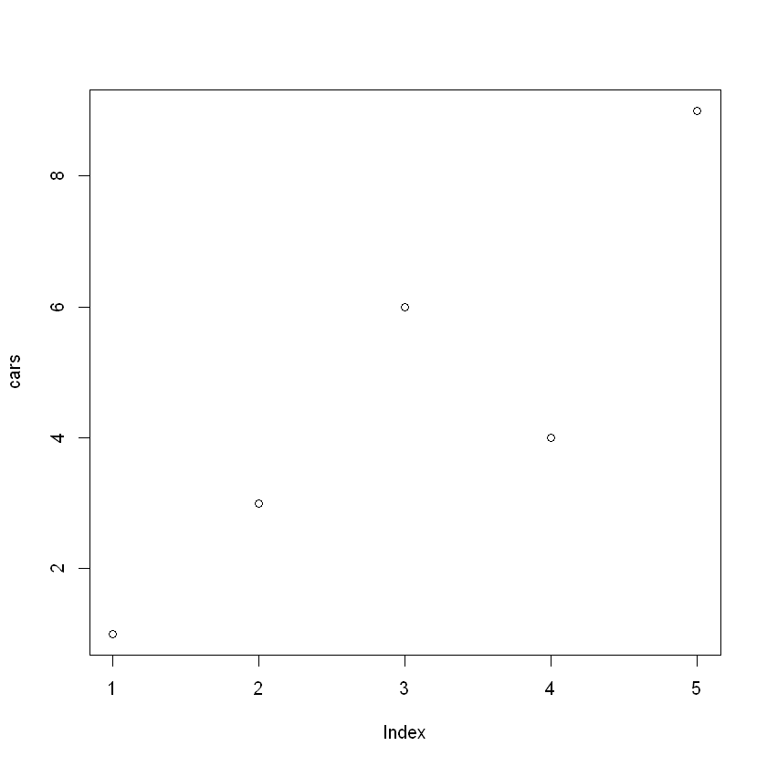

```r
# Define the cars vector with 5 values
cars <- c(1, 3, 6, 4, 9)

# Graph the cars vector with all defaults
plot(cars)
```

Sources & References  
https://www.tutorialgateway.org/r-programming//  
https://swcarpentry.github.io/r-novice-inflammation/15-supp-loops-in-depth/